# Análisis Espacial de Diversidad Marina y Relación Diversidad–Ambiente (1993–2020)

Fase 2 — Proyecto-1 OHWe 2026 | Teleostei (OBIS), H1–H3 y Anomalías Oceanográficas 0.25°

Autor/a

Grupo R Hackaton 2026

Fecha de publicación

19 de noviembre de 2026

## 1. Integración Fase 1 (`01_`) $\rightarrow$ Fase 2 (`02_`) y Evaluación de Hipótesis (`H1–H3`)

Este documento ejecuta la **Fase 2** del flujo de trabajo en `projectOBIS`, consumiendo directamente la base taxonómica curada en `01_obis_seleccion_taxonomica.qmd` (`01_obis_seleccion_taxonomica.html`):

- **Base biológica principal (`cin/obis_teleostei_1990_2025.csv`) y respaldo GBIF (`../2_DepuracionDatos.qmd`):** Toma los registros estandarizados de **`Teleostei` (OBIS)** filtrados a **`1993–2020`** (**`24,607` registros**, **`358` especies**, **`27` años** y **`74` celdas de $0.25^\circ$**). Si no estuviera disponible, retrocede automáticamente a **OBIS + GBIF** o **GBIF depurado**.
- **Serie oceanográfica real (`../datos_ERSST.R`) y Copernicus Marine (`../descarga_temperatura_copernicus_arojasar.R`):** Extrae TSM mensual de **NOAA ERSST (`data/ersst/ersst_EC.rds`)** junto con **TSM (`thetao`) y Salinidad Superficial del Mar (`so`) mensuales de Copernicus Marine (`1993–2020`)** en el corredor (`99°W–86°W`, `2°S–7°N`).
- **Grilla ambiental a $0.25^\circ$:** Combina `ambiente_galapagos_coco.tif` (Bio-ORACLE: TSM y Clorofila-*a*) y `data/copernicus_anomalias_grilla_025.csv` (Copernicus: TSM, Salinidad, anomalías espaciales y variación temporal) agregados exactamente a **$0.25^\circ \times 0.25^\circ$**.

**AdvertenciaVínculo con la Alerta Crítica de Fase 1 (`01_obis_seleccion_taxonomica.qmd`)**

Los resultados biológicos de este análisis corresponden al polígono con el que se descargó `projectOBIS` (`-98° a -90° W`, `-0.5° a 6.5° N`, concentrado en Galápagos occidental), el cual deja fuera a la **Isla del Coco** (`~87.06° W, 5.53° N`). Las capas y mapas de anomalías oceanográficas cubren el corredor completo **`-99° a -86° W`, `-2° a 7° N`**.

**Código**

```r
# Funciones métricas de Diversidad Alfa y Beta
calc_shannon <- function(conteos) {
  conteos <- conteos[conteos > 0]
  if (length(conteos) == 0) return(0)
  p <- conteos / sum(conteos)
  -sum(p * log(p))
}

calc_simpson <- function(conteos) {
  conteos <- conteos[conteos > 0]
  if (length(conteos) == 0) return(0)
  p <- conteos / sum(conteos)
  1 - sum(p^2)
}

jaccard_disim <- function(sp_a, sp_b) {
  sp_a <- unique(stats::na.omit(sp_a))
  sp_b <- unique(stats::na.omit(sp_b))
  un <- length(union(sp_a, sp_b))
  if (un == 0) return(NA_real_)
  1 - (length(intersect(sp_a, sp_b)) / un)
}

sorensen_disim <- function(sp_a, sp_b) {
  sp_a <- unique(stats::na.omit(sp_a))
  sp_b <- unique(stats::na.omit(sp_b))
  tot <- length(sp_a) + length(sp_b)
  if (tot == 0) return(NA_real_)
  1 - (2 * length(intersect(sp_a, sp_b)) / tot)
}

# 1) Carga de registros biológicos 1993-2020 (prioriza OBIS Teleostei de projectOBIS; luego OBIS+GBIF; luego GBIF depurado)
# [CONEXIÓN Fase 1 -> Fase 2] Lee cin/obis_teleostei_1990_2025.csv generado en 01_obis_seleccion_taxonomica.qmd
ruta_obis_teleostei <- if (file.exists("cin/obis_teleostei_1990_2025.csv")) {
  "cin/obis_teleostei_1990_2025.csv"
} else {
  ruta_repo("projectOBIS/cin/obis_teleostei_1990_2025.csv")
}
ruta_obis_gbif <- ruta_repo("data/registros_obis_gbif_1993_2020.csv")
ruta_gbif_dep <- ruta_repo("data/GBIF_Colon_Coco_especies_depurado.rds")

if (file.exists(ruta_obis_teleostei)) {
  registros_1993_2020 <- utils::read.csv(ruta_obis_teleostei, stringsAsFactors = FALSE) %>%
    dplyr::mutate(
      longitud = as.numeric(decimalLongitude),
      latitud = as.numeric(decimalLatitude),
      year = as.integer(year_analysis),
      species = trimws(as.character(species_accepted)),
      class = as.character(class),
      order = as.character(order),
      fuente = "OBIS Teleostei (projectOBIS)"
    ) %>%
    dplyr::filter(year >= 1993, year <= 2020, !is.na(species), species != "")
  fuente_bio <- "OBIS Teleostei oficial (projectOBIS/cin/obis_teleostei_1990_2025.csv)"
} else if (file.exists(ruta_obis_gbif)) {
  registros_1993_2020 <- utils::read.csv(ruta_obis_gbif, stringsAsFactors = FALSE) %>%
    dplyr::mutate(
      longitud = as.numeric(dplyr::coalesce(longitud, decimalLongitude)),
      latitud = as.numeric(dplyr::coalesce(latitud, decimalLatitude))
    ) %>%
    dplyr::filter(year >= 1993, year <= 2020, !is.na(species), trimws(species) != "")
  fuente_bio <- "OBIS + GBIF combinados (archivo del equipo)"
} else if (file.exists(ruta_gbif_dep)) {
  registros_1993_2020 <- base::readRDS(ruta_gbif_dep) %>%
    dplyr::rename(longitud = decimalLongitude, latitud = decimalLatitude) %>%
    dplyr::filter(year >= 1993, year <= 2020, !is.na(species), trimws(species) != "") %>%
    dplyr::mutate(fuente = "GBIF depurado (2_DepuracionDatos.qmd)")
  fuente_bio <- "GBIF depurado oficial (data/GBIF_Colon_Coco_especies_depurado.rds)"
} else {
  datos_gbif <- readxl::read_excel(ruta_repo("data/GBIF_Colon_Coco_2026_TableToExcel original descargada de Gbif.xlsx"))
  registros_1993_2020 <- depurar_gbif_corredor(datos_gbif)$fauna_marina %>%
    dplyr::filter(year >= 1993, year <= 2020, !is.na(species), trimws(species) != "") %>%
    dplyr::mutate(fuente = "GBIF depurado")
  fuente_bio <- "GBIF depurado (fallback)"
}

# 2) Carga de serie real de TSM NOAA ERSST desde data/ersst/ersst_EC.rds (1993-2020)
ersst_raw <- base::readRDS(ruta_repo("data/ersst/ersst_EC.rds"))
ersst_attr <- attributes(ersst_raw)
ersst_lon <- ersst_attr[["lon"]]
ersst_lat <- ersst_attr[["lat"]]
ersst_tm <- as.Date(ersst_attr[["period"]][["tmStart"]])
ersst_mat <- ersst_attr[["data"]] # dimensiones: lat x lon x tiempo

idx_lat <- which(ersst_lat >= -2 & ersst_lat <= 8)
idx_lon <- which(ersst_lon >= -99 & ersst_lon <= -86)
idx_t <- which(as.integer(format(ersst_tm, "%Y")) >= 1993 & as.integer(format(ersst_tm, "%Y")) <= 2020)

ersst_sub <- ersst_mat[idx_lat, idx_lon, idx_t, drop = FALSE]
ersst_yrs <- as.integer(format(ersst_tm[idx_t], "%Y"))

tsm_anual_ersst <- tibble::tibble(year = 1993:2020) %>%
  dplyr::mutate(
    tsm_media = vapply(year, function(y) {
      k <- which(ersst_yrs == y)
      round(mean(ersst_sub[, , k], na.rm = TRUE), 3)
    }, numeric(1)),
    tsm_sd = vapply(year, function(y) {
      k <- which(ersst_yrs == y)
      round(stats::sd(as.numeric(ersst_sub[, , k]), na.rm = TRUE), 3)
    }, numeric(1)),
    tsm_anomalia = round(tsm_media - mean(tsm_media, na.rm = TRUE), 3)
  )

# 3) Carga de grilla ambiental 0.25° (Bio-ORACLE + Copernicus TSM y Salinidad)
capas_bo <- cargar_capas_biooracle(ruta_repo("ambiente_galapagos_coco.tif"))
capas_025 <- terra::aggregate(capas_bo, fact = 3, fun = mean, na.rm = TRUE)
df_amb_025 <- as.data.frame(capas_025, xy = TRUE, na.rm = TRUE)
names(df_amb_025) <- c("lon_025", "lat_025", "tsm_celda", "clorofila_celda")
df_amb_025 <- df_amb_025 %>%
  dplyr::mutate(
    lon_025 = round(lon_025, 3),
    lat_025 = round(lat_025, 3)
  )

ruta_cop_anual <- ruta_repo("data/copernicus_tsm_salinidad_anual_1993_2020.csv")
ruta_cop_mensual <- ruta_repo("data/copernicus_tsm_salinidad_mensual_1993_2020.csv")
ruta_cop_anom_025 <- ruta_repo("data/copernicus_anomalias_grilla_025.csv")
ruta_cop_025 <- ruta_repo("data/copernicus_tsm_salinidad_grilla_025.csv")

df_cop_mensual <- NULL
if (file.exists(ruta_cop_mensual)) {
  df_cop_mensual <- utils::read.csv(ruta_cop_mensual, stringsAsFactors = FALSE) %>%
    dplyr::mutate(fecha = as.Date(fecha))
}

df_cop_025 <- NULL
ruta_cop_grilla_activa <- if (file.exists(ruta_cop_anom_025)) ruta_cop_anom_025 else ruta_cop_025
if (file.exists(ruta_cop_grilla_activa)) {
  df_cop_025 <- utils::read.csv(ruta_cop_grilla_activa, stringsAsFactors = FALSE) %>%
    dplyr::mutate(lon_025 = round(lon_025, 3), lat_025 = round(lat_025, 3))
  df_amb_025 <- df_amb_025 %>%
    dplyr::left_join(df_cop_025, by = c("lon_025", "lat_025"))
}

# 4) Integrar tabla anual oficial si el equipo ya la exportó, o calcular sobre datos reales actuales
ruta_anual_equipo <- ruta_repo("data/diversidad_ambiente_anual_1993_2020.csv")
ruta_grilla_equipo <- ruta_repo("data/biodiversidad_grilla_025_1993_2020.csv")

if (file.exists(ruta_anual_equipo)) {
  df_anual <- utils::read.csv(ruta_anual_equipo, stringsAsFactors = FALSE) %>%
    dplyr::filter(year >= 1993, year <= 2020) %>%
    dplyr::arrange(year)
  tiene_salinidad_anual <- "salinidad_media" %in% names(df_anual) && any(!is.na(df_anual$salinidad_media))
} else {
  especies_pool <- unique(registros_1993_2020$species)
  anios_obs <- sort(unique(registros_1993_2020$year))

  div_anual <- lapply(seq_along(anios_obs), function(idx) {
    yr <- anios_obs[idx]
    sub <- registros_1993_2020 %>% dplyr::filter(year == yr)
    cont <- sub %>% dplyr::count(species) %>% dplyr::pull(n)
    sp_yr <- unique(sub$species)
    tibble::tibble(
      year = yr,
      n_registros = nrow(sub),
      riqueza_alpha = dplyr::n_distinct(sp_yr),
      shannon_alpha = round(calc_shannon(cont), 3),
      simpson_alpha = round(calc_simpson(cont), 3),
      beta_jaccard = round(jaccard_disim(sp_yr, especies_pool), 3),
      beta_sorensen = round(sorensen_disim(sp_yr, especies_pool), 3)
    )
  }) %>%
    dplyr::bind_rows()

  df_anual <- tsm_anual_ersst %>%
    dplyr::left_join(div_anual, by = "year")
  if (file.exists(ruta_cop_anual)) {
    df_cop_anual <- utils::read.csv(ruta_cop_anual, stringsAsFactors = FALSE)
    df_anual <- df_anual %>% dplyr::left_join(df_cop_anual, by = "year")
  }
  tiene_salinidad_anual <- "salinidad_media" %in% names(df_anual) && any(!is.na(df_anual$salinidad_media))
}

# 5) Grilla espacial de 0.25° x 0.25° (1993-2020)
if (file.exists(ruta_grilla_equipo)) {
  df_grilla_025 <- utils::read.csv(ruta_grilla_equipo, stringsAsFactors = FALSE)
  tiene_salinidad_esp <- "salinidad_celda" %in% names(df_grilla_025) && any(!is.na(df_grilla_025$salinidad_celda))
} else {
  reg_celda <- registros_1993_2020 %>%
    dplyr::mutate(
      lon_025 = round(floor(longitud / 0.25) * 0.25 + 0.125, 3),
      lat_025 = round(floor(latitud / 0.25) * 0.25 + 0.125, 3)
    )

  celdas_activas <- reg_celda %>%
    dplyr::group_by(lon_025, lat_025) %>%
    dplyr::summarise(
      n_registros = dplyr::n(),
      riqueza_alpha = dplyr::n_distinct(species),
      shannon_alpha = round(calc_shannon(as.numeric(table(species))), 3),
      simpson_alpha = round(calc_simpson(as.numeric(table(species))), 3),
      n_clases = dplyr::n_distinct(class),
      clases_lista = paste(sort(unique(class)), collapse = ", "),
      especies_lista = paste(utils::head(unique(species), 5), collapse = ", "),
      anios_activos = paste(sort(unique(year)), collapse = ", "),
      .groups = "drop"
    )

  # Matriz de Beta espacial entre las celdas activas
  sp_por_celda <- split(reg_celda$species, paste(reg_celda$lon_025, reg_celda$lat_025, sep = "_"))
  llaves <- paste(celdas_activas$lon_025, celdas_activas$lat_025, sep = "_")
  n_c <- length(llaves)
  beta_esp <- numeric(n_c)
  for (i in seq_len(n_c)) {
    sp_i <- sp_por_celda[[llaves[i]]]
    dists <- vapply(seq_len(n_c), function(j) {
      if (i == j) return(NA_real_)
      jaccard_disim(sp_i, sp_por_celda[[llaves[j]]])
    }, numeric(1))
    beta_esp[i] <- round(mean(dists, na.rm = TRUE), 3)
  }
  celdas_activas$beta_jaccard <- beta_esp

  df_grilla_025 <- df_amb_025 %>%
    dplyr::left_join(celdas_activas, by = c("lon_025", "lat_025")) %>%
    dplyr::mutate(
      n_registros = tidyr::replace_na(n_registros, 0L),
      riqueza_alpha = tidyr::replace_na(riqueza_alpha, 0L)
    )
  tiene_salinidad_esp <- "salinidad_celda" %in% names(df_grilla_025) && any(!is.na(df_grilla_025$salinidad_celda))
}
```

**NotaEstado de los datos reales conectados actualmente**

- **Datos biológicos (`1993–2020`):** `OBIS Teleostei oficial (projectOBIS/cin/obis_teleostei_1990_2025.csv)` $\rightarrow$ **24607 registros** (358 especies únicas en 27 años y **74 celdas activas de $0.25^\circ$**).
- **Serie temporal de TSM (`1993–2020`):** Datos reales de **NOAA ERSST (`data/ersst/ersst_EC.rds`)** (`336` meses promediados por año; media global del periodo = 26.33 °C, pico El Niño 1997 = 27.7 °C y El Niño 2015 = 27.535 °C).
- **Ambiente espacial a $0.25^\circ$:** Datos reales de **Bio-ORACLE** (`TSM` y `Clorofila-a` agregados exactamente a $0.25^\circ$).
- **Salinidad Superficial del Mar y TSM (Copernicus Marine `1993–2020`):** `Integrada desde Copernicus (thetao y so, 1993–2020): Salinidad promedio = 33.57 PSU | TSM Copernicus = 26.36 °C.`

### Composición de la Diversidad Biológica: Comunidad Focal (`Teleostei`) vs. Subgrupos (`1993–2020`)

Los índices de diversidad calculados en este informe (**Riqueza Alfa $S$**, **Shannon $H'$**, **Simpson $1-D$** y **Beta Jaccard / Sørensen**) evalúan **todas las especies presentes en la fuente activa (358 especies únicas en 24,607 registros, `1993–2020`)**. Al conectarse con `projectOBIS/cin/obis_teleostei_1990_2025.csv`, el análisis se enfoca en la clase **`Teleostei`** seleccionada en Fase 1 y se desglosa abajo por **orden taxonómico** (top 12 + otros órdenes); si se usa la base multiclase GBIF de respaldo, se desglosa por **clase**:

**Código**

```r
total_reg_bio <- nrow(registros_1993_2020)
total_spp_bio <- dplyr::n_distinct(registros_1993_2020$species)
es_clase_unica <- dplyr::n_distinct(stats::na.omit(registros_1993_2020$class)) == 1L

resumir_taxones_bio <- function(df, col_nivel, etiqueta_col, max_filas = Inf) {
  tab <- df %>%
    dplyr::mutate(grupo = dplyr::if_else(is.na(.data[[col_nivel]]) | trimws(.data[[col_nivel]]) == "", "Sin clasificar", as.character(.data[[col_nivel]]))) %>%
    dplyr::group_by(grupo) %>%
    dplyr::summarise(
      registros = dplyr::n(),
      especies_unicas = dplyr::n_distinct(species),
      ejemplos = paste(utils::head(unique(species), 3), collapse = ", "),
      .groups = "drop"
    ) %>%
    dplyr::arrange(dplyr::desc(especies_unicas), dplyr::desc(registros))

  if (is.finite(max_filas) && nrow(tab) > max_filas) {
    top_df <- dplyr::slice_head(tab, n = max_filas)
    resto <- base::setdiff(tab$grupo, top_df$grupo)
    fila_resto <- df %>%
      dplyr::mutate(grupo = dplyr::if_else(is.na(.data[[col_nivel]]) | trimws(.data[[col_nivel]]) == "", "Sin clasificar", as.character(.data[[col_nivel]]))) %>%
      dplyr::filter(grupo %in% resto) %>%
      dplyr::summarise(
        grupo = paste0("Otros (", length(resto), " grupos)"),
        registros = dplyr::n(),
        especies_unicas = dplyr::n_distinct(species),
        ejemplos = paste(utils::head(unique(species), 3), collapse = ", ")
      )
    tab <- dplyr::bind_rows(top_df, fila_resto)
  }

  tab %>%
    dplyr::mutate(
      pct_registros = round(100 * registros / total_reg_bio, 1),
      pct_especies = round(100 * especies_unicas / total_spp_bio, 1)
    ) %>%
    dplyr::select(
      !!etiqueta_col := grupo,
      `Registros (n)` = registros,
      `% Registros` = pct_registros,
      `Especies Únicas (S)` = especies_unicas,
      `% de Riqueza Total` = pct_especies,
      `Especies Representativas` = ejemplos
    )
}

if (es_clase_unica && "order" %in% names(registros_1993_2020)) {
  tabla_grupos_bio <- resumir_taxones_bio(registros_1993_2020, "order", "Orden dentro de Teleostei", max_filas = 12L)
  cap_grupos_bio <- paste0(
    "Desglose por orden taxonómico dentro de Teleostei (OBIS 1993–2020: ",
    total_spp_bio, " especies únicas en ", format(total_reg_bio, big.mark = ","), " registros)"
  )
} else {
  tabla_grupos_bio <- resumir_taxones_bio(registros_1993_2020, "class", "Grupo Taxonómico (Clase)")
  cap_grupos_bio <- paste0(
    "Desglose por clase taxonómica de la comunidad total analizada (1993–2020: ",
    total_spp_bio, " especies únicas en ", format(total_reg_bio, big.mark = ","), " registros)"
  )
}

knitr::kable(tabla_grupos_bio, caption = cap_grupos_bio) %>%
  kableExtra::kable_styling(bootstrap_options = c("striped", "hover", "condensed"), full_width = FALSE)
```

Desglose por orden taxonómico dentro de Teleostei (OBIS 1993–2020: 358 especies únicas en 24,607 registros)

| Orden dentro de Teleostei | Registros (n) | % Registros | Especies Únicas (S) | % de Riqueza Total | Especies Representativas |
| --- | --- | --- | --- | --- | --- |
| Eupercaria incertae sedis | 7062 | 28.7 | 53 | 14.8 | Pareques perissa, Bodianus diplotaenia, Bodianus eclancheri |
| Perciformes | 3327 | 13.5 | 33 | 9.2 | Scorpaenodes xyris, Cephalopholis panamensis, Epinephelus labriformis |
| Anguilliformes | 536 | 2.2 | 31 | 8.7 | Muraena lentiginosa, Gymnothorax dovii, Ariosoma prorigerum |
| Tetraodontiformes | 2020 | 8.2 | 24 | 6.7 | Arothron meleagris, Balistes polylepis, Melichthys niger |
| Carangiformes | 530 | 2.2 | 22 | 6.1 | Caranx sexfasciatus, Elagatis bipinnulata, Seriola rivoliana |
| Myctophiformes | 172 | 0.7 | 22 | 6.1 | Bolinichthys longipes, Diogenichthys laternatus, Gonichthys tenuiculus |
| Scombriformes | 302 | 1.2 | 20 | 5.6 | Sarda orientalis, Scomberomorus sierra, Benthodesmus tenuis |
| Blenniiformes | 1909 | 7.8 | 15 | 4.2 | Chaenopsis schmitti, Labrisomus jenkinsi, Lepidonectes corallicola |
| Acanthuriformes | 2471 | 10.0 | 14 | 3.9 | Acanthurus nigricans, Chaetodon humeralis, Holacanthus passer |
| Ovalentaria incertae sedis | 2286 | 9.3 | 12 | 3.4 | Chromis alta, Abudefduf troschelii, Microspathodon bairdii |
| Aulopiformes | 103 | 0.4 | 11 | 3.1 | Bathypterois pectinatus, Chlorophthalmus mento, Lestidiops pacificus |
| Stomiiformes | 82 | 0.3 | 11 | 3.1 | Chauliodus sloani, Sternoptyx obscura, Vinciguerria lucetia |
| Otros (25 grupos) | 3807 | 15.5 | 90 | 25.1 | Abantennarius sanguineus, Bathygobius lineatus, Coryphopterus urospilus |

**TipAlcance de la comunidad analizada (`projectOBIS` vs. respaldo GBIF)**

- **Con `projectOBIS/cin/obis_teleostei_1990_2025.csv` activo (`1993–2020`):** **24,607 registros** y **358 especies de `Teleostei`** frente a los `346` registros (`65` spp.) de GBIF solo, aunque restringidos al polígono OBIS (`-98° a -90°`, `-0.5° a 6.5°`).
- **Grupos históricos excluidos:** los registros pre-1993 y microfósiles (`Globothalamea` en OBIS/GBIF) quedan excluidos al exigir continuidad multianual (`1993–2020`) emparejada con ERSST y Copernicus.

## 2. Evaluación de Hipótesis H1 — Asociación Espacial Diversidad Alfa vs. Ambiente ($0.25^\circ$)

**Hipótesis H1 (`README.md`):** *Parte de la variación espacial de la diversidad alfa registrada se asocia con gradientes de TSM y otras variables oceanográficas, incluso tras considerar cobertura observacional.*

**Correlaciones Espaciales (corrplot)**

**Código**

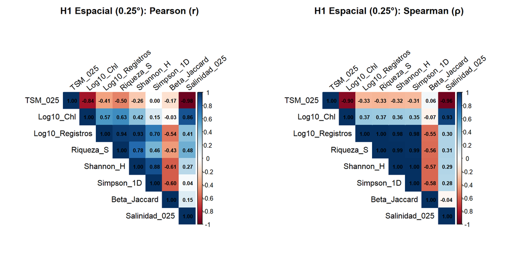

```r
celdas_h1 <- df_grilla_025 %>%
  dplyr::filter(n_registros > 0, !is.na(tsm_celda), !is.na(clorofila_celda)) %>%
  dplyr::mutate(
    log10_chl = log10(clorofila_celda),
    log10_esfuerzo = log10(n_registros)
  )

cols_h1 <- c("tsm_celda", "log10_chl", "log10_esfuerzo", "riqueza_alpha", "shannon_alpha", "simpson_alpha", "beta_jaccard")
if (tiene_salinidad_esp) cols_h1 <- c(cols_h1, "salinidad_celda")

mat_h1 <- celdas_h1 %>% dplyr::select(dplyr::all_of(cols_h1))
names(mat_h1) <- dplyr::recode(
  names(mat_h1),
  tsm_celda = "TSM_025",
  log10_chl = "Log10_Chl",
  log10_esfuerzo = "Log10_Registros",
  riqueza_alpha = "Riqueza_S",
  shannon_alpha = "Shannon_H",
  simpson_alpha = "Simpson_1D",
  beta_jaccard = "Beta_Jaccard",
  salinidad_celda = "Salinidad_025"
)

cor_h1_p <- stats::cor(mat_h1, use = "pairwise.complete.obs", method = "pearson")
cor_h1_s <- stats::cor(mat_h1, use = "pairwise.complete.obs", method = "spearman")

par(mfrow = c(1, 2))
corrplot::corrplot(
  cor_h1_p, method = "color", type = "upper", addCoef.col = "black",
  number.cex = 0.68, tl.col = "black", tl.srt = 40,
  title = "H1 Espacial (0.25°): Pearson (r)", mar = c(0, 0, 2.2, 0)
)
corrplot::corrplot(
  cor_h1_s, method = "color", type = "upper", addCoef.col = "black",
  number.cex = 0.68, tl.col = "black", tl.srt = 40,
  title = "H1 Espacial (0.25°): Spearman (ρ)", mar = c(0, 0, 2.2, 0)
)
```

**Gradientes Espaciales y Efecto de Cobertura**

**Código**

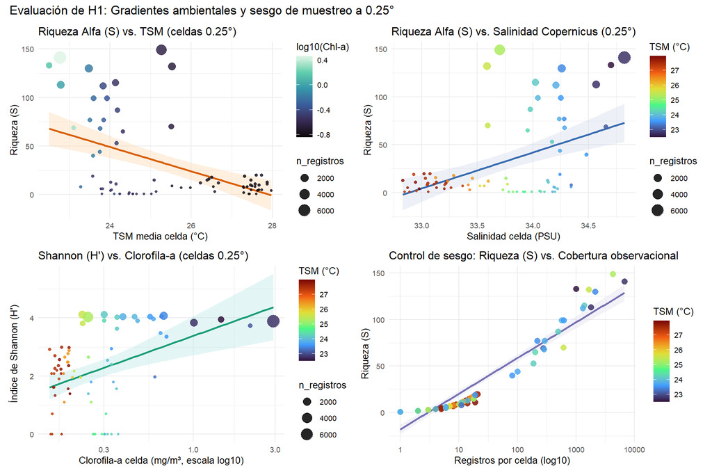

```r
p_h1_tsm <- ggplot(celdas_h1, aes(x = tsm_celda, y = riqueza_alpha)) +
  geom_smooth(method = "lm", color = "#d95f02", fill = "#fdd0a2", alpha = 0.35) +
  geom_point(aes(size = n_registros, color = log10_chl), alpha = 0.85) +
  scale_color_viridis_c(option = "mako", name = "log10(Chl-a)") +
  labs(title = "Riqueza Alfa (S) vs. TSM (celdas 0.25°)", x = "TSM media celda (°C)", y = "Riqueza (S)") +
  theme_minimal(base_size = 10)

p_h1_chl <- ggplot(celdas_h1, aes(x = clorofila_celda, y = shannon_alpha)) +
  geom_smooth(method = "lm", color = "#1b9e77", fill = "#b2e2e2", alpha = 0.35) +
  geom_point(aes(size = n_registros, color = tsm_celda), alpha = 0.85) +
  scale_x_log10() +
  scale_color_viridis_c(option = "turbo", name = "TSM (°C)") +
  labs(title = "Shannon (H') vs. Clorofila-a (celdas 0.25°)", x = "Clorofila-a celda (mg/m³, escala log10)", y = "Índice de Shannon (H')") +
  theme_minimal(base_size = 10)

p_h1_cov <- ggplot(celdas_h1, aes(x = n_registros, y = riqueza_alpha)) +
  geom_smooth(method = "lm", color = "#7570b3", fill = "#dadaeb", alpha = 0.35) +
  geom_point(aes(color = tsm_celda), size = 2.6, alpha = 0.85) +
  scale_x_log10() +
  scale_color_viridis_c(option = "turbo", name = "TSM (°C)") +
  labs(title = "Control de sesgo: Riqueza (S) vs. Cobertura observacional", x = "Registros por celda (log10)", y = "Riqueza (S)") +
  theme_minimal(base_size = 10)

# Modelo lineal múltiple evaluando ambiente + esfuerzo observacional
if (tiene_salinidad_esp) {
  p_h1_sal <- ggplot(celdas_h1, aes(x = salinidad_celda, y = riqueza_alpha)) +
    geom_smooth(method = "lm", color = "#386cb0", fill = "#cbd5e8", alpha = 0.35) +
    geom_point(aes(size = n_registros, color = tsm_celda), alpha = 0.85) +
    scale_color_viridis_c(option = "turbo", name = "TSM (°C)") +
    labs(title = "Riqueza Alfa (S) vs. Salinidad Copernicus (0.25°)", x = "Salinidad celda (PSU)", y = "Riqueza (S)") +
    theme_minimal(base_size = 10)
  mod_h1 <- stats::lm(riqueza_alpha ~ tsm_celda + salinidad_celda + log10_chl + log10_esfuerzo, data = celdas_h1)
  panel_h1_plots <- (p_h1_tsm + p_h1_sal) / (p_h1_chl + p_h1_cov)
  cap_h1 <- paste0("Modelo lineal H1: Riqueza Alfa ~ TSM + Salinidad + log10(Chl-a) + log10(Cobertura) | R² ajustado = ", round(summary(mod_h1)$adj.r.squared, 3))
} else {
  mod_h1 <- stats::lm(riqueza_alpha ~ tsm_celda + log10_chl + log10_esfuerzo, data = celdas_h1)
  panel_h1_plots <- (p_h1_tsm + p_h1_chl) / p_h1_cov
  cap_h1 <- paste0("Modelo lineal H1: Riqueza Alfa ~ TSM + log10(Chl-a) + log10(Cobertura) | R² ajustado = ", round(summary(mod_h1)$adj.r.squared, 3))
}

df_mod_h1 <- as.data.frame(summary(mod_h1)$coefficients)
df_mod_h1$Predictor <- rownames(df_mod_h1)
df_mod_h1 <- df_mod_h1 %>%
  dplyr::select(Predictor, Estimado = Estimate, Error_Std = `Std. Error`, t = `t value`, p_valor = `Pr(>|t|)`) %>%
  dplyr::mutate(dplyr::across(c(Estimado, Error_Std, t), ~ round(.x, 3)), p_valor = signif(p_valor, 3))

panel_h1_plots +
  plot_annotation(title = "Evaluación de H1: Gradientes ambientales y sesgo de muestreo a 0.25°")
```

**Código**

```r
knitr::kable(df_mod_h1, row.names = FALSE, caption = cap_h1) %>%
  kableExtra::kable_styling(bootstrap_options = c("striped", "hover", "condensed"), full_width = FALSE)
```

Modelo lineal H1: Riqueza Alfa ~ TSM + Salinidad + log10(Chl-a) + log10(Cobertura) | R² ajustado = 0.91

| Predictor | Estimado | Error_Std | t | p_valor |
| --- | --- | --- | --- | --- |
| (Intercept) | 1575.716 | 606.059 | 2.600 | 0.01140 |
| tsm_celda | -13.092 | 4.374 | -2.993 | 0.00383 |
| salinidad_celda | -36.991 | 14.789 | -2.501 | 0.01480 |
| log10_chl | 17.326 | 12.416 | 1.395 | 0.16700 |
| log10_esfuerzo | 35.084 | 1.777 | 19.747 | 0.00000 |

## 3. Evaluación de Hipótesis H2 — Diversidad Beta Espacial vs. Distancia Ambiental ($0.25^\circ$)

**Hipótesis H2 (`README.md`):** *Las celdas con condiciones oceanográficas más diferentes presentan mayor disimilitud en composición de especies (diversidad beta espacial).*

**Código**

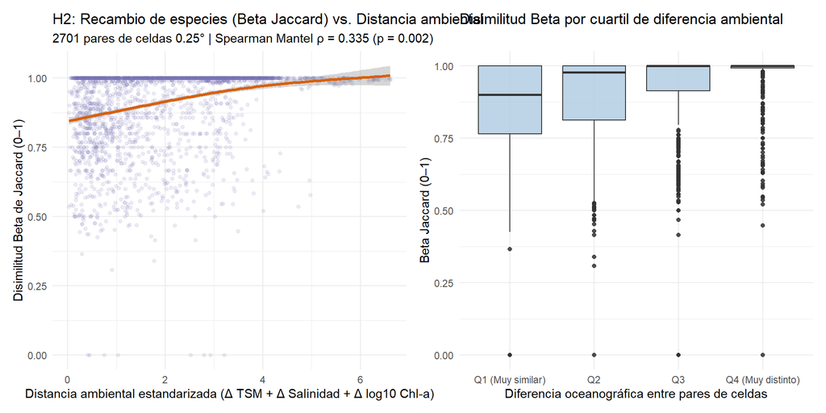

```r
# Construir tabla de pares únicos entre las celdas activas de 0.25°
reg_celda_h2 <- registros_1993_2020 %>%
  dplyr::mutate(
    lon_025 = round(floor(longitud / 0.25) * 0.25 + 0.125, 3),
    lat_025 = round(floor(latitud / 0.25) * 0.25 + 0.125, 3),
    celda_id = paste(lon_025, lat_025, sep = "_")
  )

celdas_h2 <- celdas_h1 %>%
  dplyr::mutate(
    celda_id = paste(lon_025, lat_025, sep = "_"),
    z_tsm = as.numeric(scale(tsm_celda)),
    z_chl = as.numeric(scale(log10_chl)),
    z_sal = if (tiene_salinidad_esp) as.numeric(scale(salinidad_celda)) else 0
  )

sp_lista_h2 <- split(reg_celda_h2$species, reg_celda_h2$celda_id)
n_h2 <- nrow(celdas_h2)

pares_idx <- utils::combn(n_h2, 2)
n_pares <- ncol(pares_idx)

beta_jacc_par <- numeric(n_pares)
beta_sor_par <- numeric(n_pares)
dist_amb_par <- numeric(n_pares)
dist_geo_par <- numeric(n_pares)

for (k in seq_len(n_pares)) {
  i <- pares_idx[1, k]
  j <- pares_idx[2, k]
  id_i <- celdas_h2$celda_id[i]
  id_j <- celdas_h2$celda_id[j]
  beta_jacc_par[k] <- jaccard_disim(sp_lista_h2[[id_i]], sp_lista_h2[[id_j]])
  beta_sor_par[k] <- sorensen_disim(sp_lista_h2[[id_i]], sp_lista_h2[[id_j]])
  dist_amb_par[k] <- sqrt(
    (celdas_h2$z_tsm[i] - celdas_h2$z_tsm[j])^2 +
      (celdas_h2$z_chl[i] - celdas_h2$z_chl[j])^2 +
      (celdas_h2$z_sal[i] - celdas_h2$z_sal[j])^2
  )
  dist_geo_par[k] <- distancia_haversine_km(
    celdas_h2$lon_025[i], celdas_h2$lat_025[i],
    celdas_h2$lon_025[j], celdas_h2$lat_025[j]
  )
}

df_h2_pares <- tibble::tibble(
  beta_jaccard = beta_jacc_par,
  beta_sorensen = beta_sor_par,
  dist_ambiental = dist_amb_par,
  dist_geografica_km = dist_geo_par
)

# Test de correlación tipo Mantel (Spearman con 499 permutaciones de etiquetas de celda)
set.seed(2026)
cor_obs_h2 <- stats::cor(df_h2_pares$dist_ambiental, df_h2_pares$beta_jaccard, method = "spearman", use = "complete.obs")

# Construir matriz cuadrada de disimilitud y distancia ambiental para permutación de filas/columnas
mat_beta <- matrix(0, n_h2, n_h2)
mat_amb <- matrix(0, n_h2, n_h2)
for (k in seq_len(n_pares)) {
  i <- pares_idx[1, k]
  j <- pares_idx[2, k]
  mat_beta[i, j] <- mat_beta[j, i] <- beta_jacc_par[k]
  mat_amb[i, j] <- mat_amb[j, i] <- dist_amb_par[k]
}
tri_idx <- upper.tri(mat_beta)
perm_cors <- replicate(499, {
  ord <- sample.int(n_h2)
  stats::cor(mat_amb[tri_idx], mat_beta[ord, ord][tri_idx], method = "spearman", use = "complete.obs")
})
p_mantel_h2 <- (sum(perm_cors >= cor_obs_h2) + 1) / 500

p_h2_1 <- ggplot(df_h2_pares, aes(x = dist_ambiental, y = beta_jaccard)) +
  geom_point(alpha = 0.14, color = "#7570b3", size = 1.2) +
  geom_smooth(method = "gam", formula = y ~ s(x, k = 4), color = "#d95f02", linewidth = 1.1) +
  labs(
    title = "H2: Recambio de especies (Beta Jaccard) vs. Distancia ambiental",
    subtitle = paste0(
      n_pares, " pares de celdas 0.25° | Spearman Mantel ρ = ",
      round(cor_obs_h2, 3), " (p = ", signif(p_mantel_h2, 3), ")"
    ),
    x = ifelse(tiene_salinidad_esp, "Distancia ambiental estandarizada (Δ TSM + Δ Salinidad + Δ log10 Chl-a)", "Distancia ambiental estandarizada (Δ TSM + Δ log10 Chl-a)"),
    y = "Disimilitud Beta de Jaccard (0–1)"
  ) +
  theme_minimal(base_size = 11)

p_h2_2 <- df_h2_pares %>%
  dplyr::mutate(cuartil_amb = dplyr::ntile(dist_ambiental, 4)) %>%
  ggplot(aes(x = factor(cuartil_amb, labels = c("Q1 (Muy similar)", "Q2", "Q3", "Q4 (Muy distinto)")), y = beta_jaccard)) +
  geom_boxplot(fill = "#b3cde3", alpha = 0.85) +
  labs(
    title = "Disimilitud Beta por cuartil de diferencia ambiental",
    x = "Diferencia oceanográfica entre pares de celdas",
    y = "Beta Jaccard (0–1)"
  ) +
  theme_minimal(base_size = 11)

p_h2_1 + p_h2_2
```

## 4. Evaluación de Hipótesis H3 — Variación Interanual (`1993–2020`, `ersst_EC.rds` + Copernicus)

**Hipótesis H3 (`README.md`):** *Cambios interanuales de TSM y Salinidad se asocian con cambios en indicadores de diversidad, considerando las limitaciones de cobertura y comparabilidad observacional entre años.*

**Series Temporales (1993–2020)**

**Código**

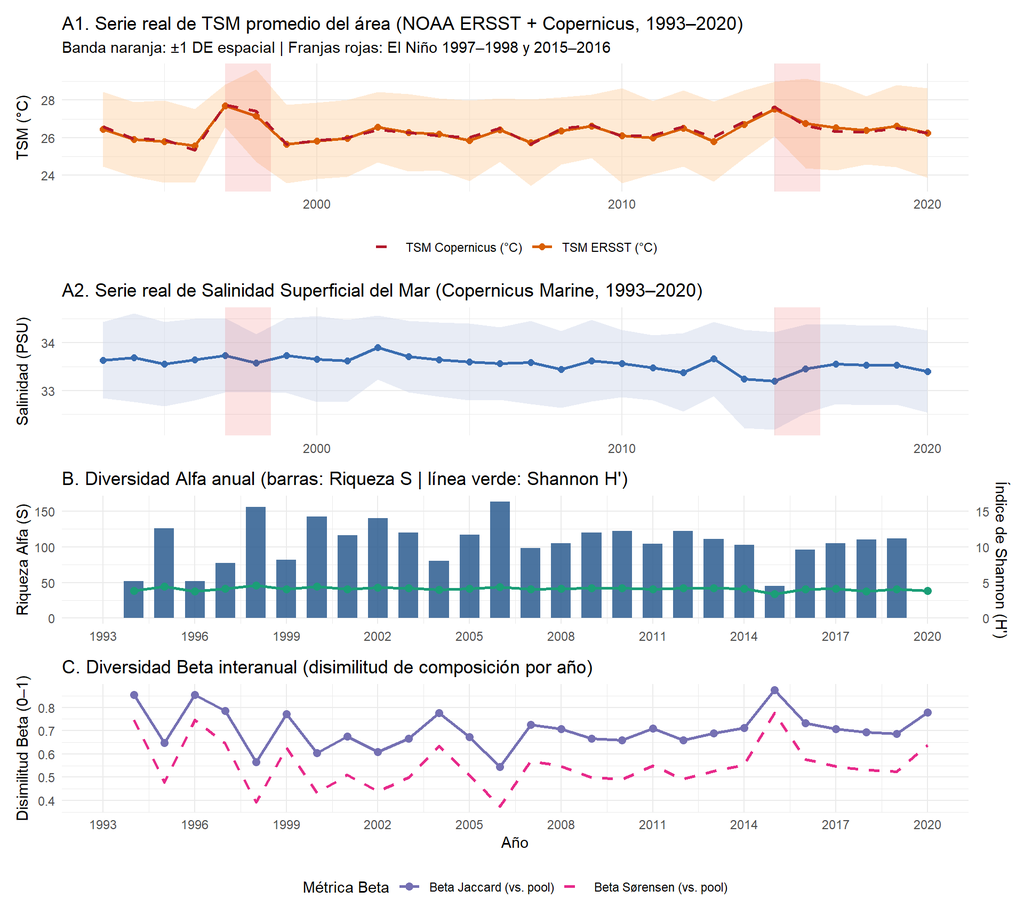

```r
df_anual_obs <- df_anual %>% dplyr::filter(!is.na(riqueza_alpha))

p_h3_tsm <- ggplot(df_anual, aes(x = year, y = tsm_media)) +
  geom_ribbon(aes(ymin = tsm_media - tsm_sd, ymax = tsm_media + tsm_sd), fill = "#fdd0a2", alpha = 0.45) +
  geom_line(aes(color = "TSM ERSST (°C)"), linewidth = 1.05) +
  geom_point(aes(color = "TSM ERSST (°C)"), size = 2) +
  {if ("tsm_copernicus" %in% names(df_anual)) geom_line(aes(y = tsm_copernicus, color = "TSM Copernicus (°C)"), linewidth = 0.9, linetype = "dashed")} +
  annotate("rect", xmin = 1997, xmax = 1998.5, ymin = -Inf, ymax = Inf, alpha = 0.12, fill = "#e31a1c") +
  annotate("rect", xmin = 2015, xmax = 2016.5, ymin = -Inf, ymax = Inf, alpha = 0.12, fill = "#e31a1c") +
  scale_color_manual(values = c("TSM ERSST (°C)" = "#d95f02", "TSM Copernicus (°C)" = "#b2182b"), name = NULL) +
  labs(
    title = "A1. Serie real de TSM promedio del área (NOAA ERSST + Copernicus, 1993–2020)",
    subtitle = "Banda naranja: ±1 DE espacial | Franjas rojas: El Niño 1997–1998 y 2015–2016",
    x = NULL, y = "TSM (°C)"
  ) +
  theme_minimal(base_size = 11) +
  theme(legend.position = "bottom")

p_h3_sal <- if (tiene_salinidad_anual) {
  ggplot(df_anual, aes(x = year, y = salinidad_media)) +
    geom_ribbon(aes(ymin = salinidad_media - salinidad_sd, ymax = salinidad_media + salinidad_sd), fill = "#cbd5e8", alpha = 0.45) +
    geom_line(color = "#386cb0", linewidth = 1.05) +
    geom_point(color = "#386cb0", size = 2) +
    annotate("rect", xmin = 1997, xmax = 1998.5, ymin = -Inf, ymax = Inf, alpha = 0.12, fill = "#e31a1c") +
    annotate("rect", xmin = 2015, xmax = 2016.5, ymin = -Inf, ymax = Inf, alpha = 0.12, fill = "#e31a1c") +
    labs(title = "A2. Serie real de Salinidad Superficial del Mar (Copernicus Marine, 1993–2020)", x = NULL, y = "Salinidad (PSU)") +
    theme_minimal(base_size = 11)
} else NULL

p_h3_alpha <- ggplot(df_anual_obs, aes(x = year)) +
  geom_col(aes(y = riqueza_alpha), fill = "#2b5c8f", alpha = 0.85, width = 0.65) +
  geom_line(aes(y = shannon_alpha * 10, group = 1), color = "#1b9e77", linewidth = 1) +
  geom_point(aes(y = shannon_alpha * 10), color = "#1b9e77", size = 2.3) +
  scale_y_continuous(
    name = "Riqueza Alfa (S)",
    sec.axis = sec_axis(~ . / 10, name = "Índice de Shannon (H')")
  ) +
  scale_x_continuous(limits = c(1993, 2020), breaks = seq(1993, 2020, by = 3)) +
  labs(
    title = "B. Diversidad Alfa anual (barras: Riqueza S | línea verde: Shannon H')",
    x = NULL
  ) +
  theme_minimal(base_size = 11)

p_h3_beta <- ggplot(df_anual_obs, aes(x = year)) +
  geom_line(aes(y = beta_jaccard, color = "Beta Jaccard (vs. pool)"), linewidth = 1) +
  geom_point(aes(y = beta_jaccard, color = "Beta Jaccard (vs. pool)"), size = 2.3) +
  geom_line(aes(y = beta_sorensen, color = "Beta Sørensen (vs. pool)"), linewidth = 0.9, linetype = "dashed") +
  scale_color_manual(
    values = c("Beta Jaccard (vs. pool)" = "#7570b3", "Beta Sørensen (vs. pool)" = "#e7298a"),
    name = "Métrica Beta"
  ) +
  scale_x_continuous(limits = c(1993, 2020), breaks = seq(1993, 2020, by = 3)) +
  labs(
    title = "C. Diversidad Beta interanual (disimilitud de composición por año)",
    x = "Año", y = "Disimilitud Beta (0–1)"
  ) +
  theme_minimal(base_size = 11) +
  theme(legend.position = "bottom")

if (!is.null(p_h3_sal)) {
  (p_h3_tsm / p_h3_sal / p_h3_alpha / p_h3_beta)
} else {
  (p_h3_tsm / p_h3_alpha / p_h3_beta)
}
```

**Correlación Interanual (corrplot y Dispersión)**

**Código**

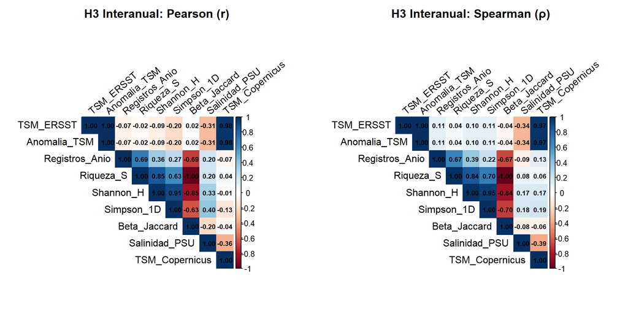

```r
cols_h3 <- c("tsm_media", "tsm_anomalia", "n_registros", "riqueza_alpha", "shannon_alpha", "simpson_alpha", "beta_jaccard")
if (tiene_salinidad_anual) cols_h3 <- c(cols_h3, "salinidad_media", "tsm_copernicus")

mat_h3 <- df_anual_obs %>% dplyr::select(dplyr::any_of(cols_h3))
names(mat_h3) <- dplyr::recode(
  names(mat_h3),
  tsm_media = "TSM_ERSST",
  tsm_anomalia = "Anomalia_TSM",
  tsm_copernicus = "TSM_Copernicus",
  salinidad_media = "Salinidad_PSU",
  n_registros = "Registros_Anio",
  riqueza_alpha = "Riqueza_S",
  shannon_alpha = "Shannon_H",
  simpson_alpha = "Simpson_1D",
  beta_jaccard = "Beta_Jaccard"
)

par(mfrow = c(1, 2))
corrplot::corrplot(
  stats::cor(mat_h3, use = "pairwise.complete.obs", method = "pearson"),
  method = "color", type = "upper", addCoef.col = "black",
  number.cex = 0.65, tl.col = "black", tl.srt = 40,
  title = "H3 Interanual: Pearson (r)", mar = c(0, 0, 2.2, 0)
)
corrplot::corrplot(
  stats::cor(mat_h3, use = "pairwise.complete.obs", method = "spearman"),
  method = "color", type = "upper", addCoef.col = "black",
  number.cex = 0.65, tl.col = "black", tl.srt = 40,
  title = "H3 Interanual: Spearman (ρ)", mar = c(0, 0, 2.2, 0)
)
```

**Código**

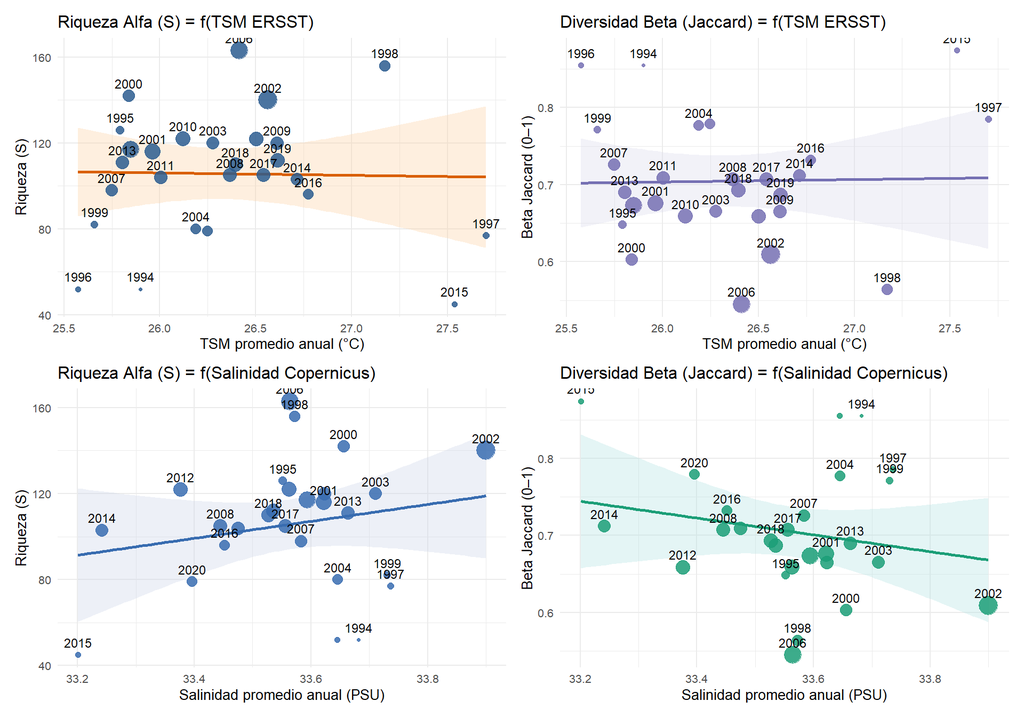

```r
g_h3_a <- ggplot(df_anual_obs, aes(x = tsm_media, y = riqueza_alpha)) +
  geom_smooth(method = "lm", color = "#d95f02", fill = "#fdd0a2", alpha = 0.35) +
  geom_point(aes(size = n_registros), color = "#2b5c8f", alpha = 0.85) +
  geom_text(aes(label = year), vjust = -0.8, size = 3, check_overlap = TRUE) +
  labs(title = "Riqueza Alfa (S) = f(TSM ERSST)", x = "TSM promedio anual (°C)", y = "Riqueza (S)") +
  theme_minimal(base_size = 10) +
  theme(legend.position = "none")

g_h3_b <- ggplot(df_anual_obs, aes(x = tsm_media, y = beta_jaccard)) +
  geom_smooth(method = "lm", color = "#7570b3", fill = "#dadaeb", alpha = 0.35) +
  geom_point(aes(size = n_registros), color = "#7570b3", alpha = 0.85) +
  geom_text(aes(label = year), vjust = -0.8, size = 3, check_overlap = TRUE) +
  labs(title = "Diversidad Beta (Jaccard) = f(TSM ERSST)", x = "TSM promedio anual (°C)", y = "Beta Jaccard (0–1)") +
  theme_minimal(base_size = 10) +
  theme(legend.position = "none")

if (tiene_salinidad_anual) {
  g_h3_c <- ggplot(df_anual_obs, aes(x = salinidad_media, y = riqueza_alpha)) +
    geom_smooth(method = "lm", color = "#386cb0", fill = "#cbd5e8", alpha = 0.35) +
    geom_point(aes(size = n_registros), color = "#386cb0", alpha = 0.85) +
    geom_text(aes(label = year), vjust = -0.8, size = 3, check_overlap = TRUE) +
    labs(title = "Riqueza Alfa (S) = f(Salinidad Copernicus)", x = "Salinidad promedio anual (PSU)", y = "Riqueza (S)") +
    theme_minimal(base_size = 10) +
    theme(legend.position = "none")

  g_h3_d <- ggplot(df_anual_obs, aes(x = salinidad_media, y = beta_jaccard)) +
    geom_smooth(method = "lm", color = "#1b9e77", fill = "#b2e2e2", alpha = 0.35) +
    geom_point(aes(size = n_registros), color = "#1b9e77", alpha = 0.85) +
    geom_text(aes(label = year), vjust = -0.8, size = 3, check_overlap = TRUE) +
    labs(title = "Diversidad Beta (Jaccard) = f(Salinidad Copernicus)", x = "Salinidad promedio anual (PSU)", y = "Beta Jaccard (0–1)") +
    theme_minimal(base_size = 10) +
    theme(legend.position = "none")

  (g_h3_a + g_h3_b) / (g_h3_c + g_h3_d)
} else {
  g_h3_a + g_h3_b
}
```

**Tabla Anual Integrada (1993–2020)**

**Código**

```r
tabla_h3 <- df_anual_obs %>%
  dplyr::select(
    Año = year,
    `TSM ERSST (°C)` = tsm_media,
    dplyr::any_of(c(`TSM Cop. (°C)` = "tsm_copernicus", `Salinidad (PSU)` = "salinidad_media")),
    `Anomalía TSM (°C)` = tsm_anomalia,
    Registros = n_registros,
    `Riqueza (S)` = riqueza_alpha,
    `Shannon (H')` = shannon_alpha,
    `Simpson (1-D)` = simpson_alpha,
    `Beta Jaccard` = beta_jaccard,
    `Beta Sørensen` = beta_sorensen
  )

knitr::kable(tabla_h3, caption = "Serie anual observada (1993–2020): TSM (ERSST/Copernicus), Salinidad (Copernicus) y diversidad") %>%
  kableExtra::kable_styling(bootstrap_options = c("striped", "hover", "condensed"), full_width = FALSE)
```

Serie anual observada (1993–2020): TSM (ERSST/Copernicus), Salinidad (Copernicus) y diversidad

| Año | TSM ERSST (°C) | TSM Cop. (°C) | Salinidad (PSU) | Anomalía TSM (°C) | Registros | Riqueza (S) | Shannon (H') | Simpson (1-D) | Beta Jaccard | Beta Sørensen |
| --- | --- | --- | --- | --- | --- | --- | --- | --- | --- | --- |
| 1994 | 25.900 | 25.951 | 33.682 | -0.433 | 75 | 52 | 3.853 | 0.976 | 0.855 | 0.746 |
| 1995 | 25.792 | 25.926 | 33.552 | -0.541 | 309 | 126 | 4.477 | 0.984 | 0.648 | 0.479 |
| 1996 | 25.574 | 25.342 | 33.645 | -0.759 | 107 | 52 | 3.744 | 0.971 | 0.855 | 0.746 |
| 1997 | 27.700 | 27.758 | 33.736 | 1.367 | 175 | 77 | 4.142 | 0.981 | 0.785 | 0.646 |
| 1998 | 27.171 | 27.427 | 33.572 | 0.838 | 612 | 156 | 4.566 | 0.984 | 0.564 | 0.393 |
| 1999 | 25.660 | 25.662 | 33.731 | -0.673 | 216 | 82 | 4.081 | 0.975 | 0.771 | 0.627 |
| 2000 | 25.838 | 25.843 | 33.656 | -0.495 | 747 | 142 | 4.452 | 0.983 | 0.603 | 0.432 |
| 2001 | 25.963 | 25.999 | 33.622 | -0.370 | 1635 | 116 | 4.086 | 0.975 | 0.676 | 0.511 |
| 2002 | 26.564 | 26.436 | 33.900 | 0.231 | 2463 | 140 | 4.277 | 0.980 | 0.609 | 0.438 |
| 2003 | 26.278 | 26.288 | 33.711 | -0.055 | 914 | 120 | 4.194 | 0.979 | 0.665 | 0.498 |
| 2004 | 26.189 | 26.125 | 33.646 | -0.144 | 570 | 80 | 3.973 | 0.976 | 0.777 | 0.635 |
| 2005 | 25.849 | 26.014 | 33.594 | -0.484 | 1789 | 117 | 4.120 | 0.978 | 0.673 | 0.507 |
| 2006 | 26.412 | 26.497 | 33.564 | 0.079 | 2055 | 163 | 4.361 | 0.982 | 0.545 | 0.374 |
| 2007 | 25.748 | 25.661 | 33.583 | -0.585 | 783 | 98 | 4.066 | 0.977 | 0.726 | 0.570 |
| 2008 | 26.367 | 26.491 | 33.445 | 0.034 | 1119 | 105 | 4.134 | 0.979 | 0.707 | 0.546 |
| 2009 | 26.611 | 26.679 | 33.623 | 0.278 | 1037 | 120 | 4.211 | 0.980 | 0.665 | 0.498 |
| 2010 | 26.120 | 26.090 | 33.563 | -0.213 | 1342 | 122 | 4.216 | 0.980 | 0.659 | 0.492 |
| 2011 | 26.004 | 26.137 | 33.475 | -0.329 | 999 | 104 | 4.096 | 0.978 | 0.709 | 0.550 |
| 2012 | 26.501 | 26.586 | 33.376 | 0.168 | 1199 | 122 | 4.240 | 0.981 | 0.659 | 0.492 |
| 2013 | 25.803 | 26.030 | 33.663 | -0.530 | 1024 | 111 | 4.211 | 0.981 | 0.690 | 0.527 |
| 2014 | 26.715 | 26.859 | 33.242 | 0.382 | 869 | 103 | 4.173 | 0.980 | 0.712 | 0.553 |
| 2015 | 27.535 | 27.656 | 33.201 | 1.202 | 117 | 45 | 3.411 | 0.953 | 0.874 | 0.777 |
| 2016 | 26.774 | 26.646 | 33.452 | 0.441 | 511 | 96 | 4.068 | 0.976 | 0.732 | 0.577 |
| 2017 | 26.542 | 26.346 | 33.556 | 0.209 | 1071 | 105 | 4.120 | 0.978 | 0.707 | 0.546 |
| 2018 | 26.394 | 26.312 | 33.527 | 0.061 | 1170 | 110 | 3.805 | 0.962 | 0.693 | 0.530 |
| 2019 | 26.614 | 26.521 | 33.535 | 0.281 | 1181 | 112 | 4.040 | 0.975 | 0.687 | 0.523 |
| 2020 | 26.248 | 26.266 | 33.396 | -0.085 | 518 | 79 | 3.867 | 0.972 | 0.779 | 0.638 |

**Serie Mensual Copernicus (336 meses, 1993–2020) y Ciclo Estacional**

La serie mensual completa de **336 meses** (`1993-01` a `2020-12`, profundidad superficial `0.494 m`) exportada por `descarga_temperatura_copernicus_arojasar.R` hacia `data/copernicus_tsm_salinidad_mensual_1993_2020.csv` captura la variabilidad intra-anual del corredor marino (ciclo estacional y pulsos ENSO) que queda suavizada en los promedios anuales.

**Código**

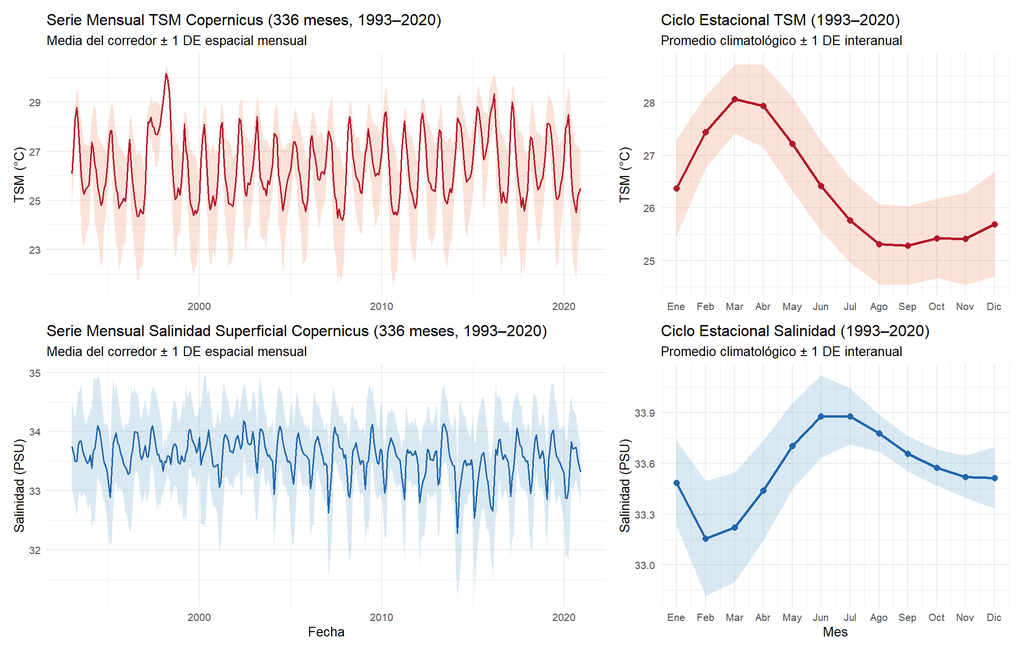

```r
if (!is.null(df_cop_mensual) && nrow(df_cop_mensual) > 0) {
  meses_abrev <- c("Ene", "Feb", "Mar", "Abr", "May", "Jun", "Jul", "Ago", "Sep", "Oct", "Nov", "Dic")

  ciclo_estacional <- df_cop_mensual %>%
    dplyr::group_by(month) %>%
    dplyr::summarise(
      tsm_prom = round(mean(tsm_copernicus, na.rm = TRUE), 3),
      tsm_sd_inter = round(stats::sd(tsm_copernicus, na.rm = TRUE), 3),
      tsm_min_hist = round(min(tsm_min, na.rm = TRUE), 3),
      tsm_max_hist = round(max(tsm_max, na.rm = TRUE), 3),
      sal_prom = round(mean(salinidad_media, na.rm = TRUE), 3),
      sal_sd_inter = round(stats::sd(salinidad_media, na.rm = TRUE), 3),
      sal_min_hist = round(min(salinidad_min, na.rm = TRUE), 3),
      sal_max_hist = round(max(salinidad_max, na.rm = TRUE), 3),
      .groups = "drop"
    ) %>%
    dplyr::mutate(mes = factor(meses_abrev[month], levels = meses_abrev))

  p_m_tsm <- ggplot(df_cop_mensual, aes(x = fecha, y = tsm_copernicus)) +
    geom_ribbon(aes(ymin = tsm_copernicus - tsm_sd_copernicus, ymax = tsm_copernicus + tsm_sd_copernicus),
                fill = "#ef8a62", alpha = 0.25) +
    geom_line(color = "#b2182b", linewidth = 0.55) +
    labs(
      title = "Serie Mensual TSM Copernicus (336 meses, 1993–2020)",
      subtitle = "Media del corredor ± 1 DE espacial mensual",
      x = NULL, y = "TSM (°C)"
    ) +
    theme_minimal(base_size = 10)

  p_m_sal <- ggplot(df_cop_mensual, aes(x = fecha, y = salinidad_media)) +
    geom_ribbon(aes(ymin = salinidad_media - salinidad_sd, ymax = salinidad_media + salinidad_sd),
                fill = "#67a9cf", alpha = 0.25) +
    geom_line(color = "#2166ac", linewidth = 0.55) +
    labs(
      title = "Serie Mensual Salinidad Superficial Copernicus (336 meses, 1993–2020)",
      subtitle = "Media del corredor ± 1 DE espacial mensual",
      x = "Fecha", y = "Salinidad (PSU)"
    ) +
    theme_minimal(base_size = 10)

  p_c_tsm <- ggplot(ciclo_estacional, aes(x = month, y = tsm_prom)) +
    geom_ribbon(aes(ymin = tsm_prom - tsm_sd_inter, ymax = tsm_prom + tsm_sd_inter),
                fill = "#ef8a62", alpha = 0.25) +
    geom_line(color = "#b2182b", linewidth = 0.9) +
    geom_point(color = "#b2182b", size = 2) +
    scale_x_continuous(breaks = 1:12, labels = meses_abrev) +
    labs(
      title = "Ciclo Estacional TSM (1993–2020)",
      subtitle = "Promedio climatológico ± 1 DE interanual",
      x = NULL, y = "TSM (°C)"
    ) +
    theme_minimal(base_size = 10)

  p_c_sal <- ggplot(ciclo_estacional, aes(x = month, y = sal_prom)) +
    geom_ribbon(aes(ymin = sal_prom - sal_sd_inter, ymax = sal_prom + sal_sd_inter),
                fill = "#67a9cf", alpha = 0.25) +
    geom_line(color = "#2166ac", linewidth = 0.9) +
    geom_point(color = "#2166ac", size = 2) +
    scale_x_continuous(breaks = 1:12, labels = meses_abrev) +
    labs(
      title = "Ciclo Estacional Salinidad (1993–2020)",
      subtitle = "Promedio climatológico ± 1 DE interanual",
      x = "Mes", y = "Salinidad (PSU)"
    ) +
    theme_minimal(base_size = 10)

  patchwork::wrap_plots(p_m_tsm, p_c_tsm, p_m_sal, p_c_sal, ncol = 2, widths = c(1.6, 1))
}
```

**Código**

```r
if (!is.null(df_cop_mensual) && nrow(df_cop_mensual) > 0) {
  tabla_ciclo <- ciclo_estacional %>%
    dplyr::select(
      Mes = mes,
      `TSM Media (°C)` = tsm_prom,
      `TSM DE Interanual` = tsm_sd_inter,
      `TSM Mín Hist. (°C)` = tsm_min_hist,
      `TSM Máx Hist. (°C)` = tsm_max_hist,
      `Salinidad Media (PSU)` = sal_prom,
      `Sal. DE Interanual` = sal_sd_inter,
      `Sal. Mín Hist. (PSU)` = sal_min_hist,
      `Sal. Máx Hist. (PSU)` = sal_max_hist
    )

  knitr::kable(
    tabla_ciclo,
    caption = paste0(
      "Climatología estacional Copernicus (Ene–Dic, sintetizada a partir de ",
      nrow(df_cop_mensual),
      " meses completos en data/copernicus_tsm_salinidad_mensual_1993_2020.csv)"
    )
  ) %>%
    kableExtra::kable_styling(bootstrap_options = c("striped", "hover", "condensed"), full_width = FALSE)
}
```

Climatología estacional Copernicus (Ene–Dic, sintetizada a partir de 336 meses completos en data/copernicus_tsm_salinidad_mensual_1993_2020.csv)

| Mes | TSM Media (°C) | TSM DE Interanual | TSM Mín Hist. (°C) | TSM Máx Hist. (°C) | Salinidad Media (PSU) | Sal. DE Interanual | Sal. Mín Hist. (PSU) | Sal. Máx Hist. (PSU) |
| --- | --- | --- | --- | --- | --- | --- | --- | --- |
| Ene | 26.373 | 0.916 | 22.033 | 30.591 | 33.485 | 0.252 | 30.053 | 35.372 |
| Feb | 27.444 | 0.682 | 22.143 | 30.775 | 33.156 | 0.340 | 29.733 | 35.421 |
| Mar | 28.069 | 0.653 | 21.554 | 31.152 | 33.221 | 0.325 | 29.705 | 35.504 |
| Abr | 27.936 | 0.784 | 19.890 | 31.399 | 33.440 | 0.296 | 30.573 | 35.490 |
| May | 27.215 | 0.888 | 19.296 | 30.428 | 33.702 | 0.258 | 31.034 | 35.516 |
| Jun | 26.416 | 0.857 | 17.747 | 30.101 | 33.877 | 0.243 | 31.661 | 35.371 |
| Jul | 25.763 | 0.803 | 17.464 | 30.366 | 33.878 | 0.166 | 31.651 | 35.432 |
| Ago | 25.315 | 0.765 | 17.270 | 30.113 | 33.778 | 0.110 | 31.683 | 35.359 |
| Sep | 25.289 | 0.746 | 16.303 | 29.694 | 33.657 | 0.103 | 31.549 | 35.324 |
| Oct | 25.425 | 0.755 | 17.547 | 30.045 | 33.575 | 0.108 | 31.361 | 35.234 |
| Nov | 25.410 | 0.872 | 16.363 | 29.577 | 33.521 | 0.126 | 31.677 | 35.261 |
| Dic | 25.688 | 0.994 | 18.877 | 30.339 | 33.515 | 0.183 | 31.343 | 35.269 |

**Código**

```r
if (!is.null(df_cop_mensual) && nrow(df_cop_mensual) > 0) {
  muestra_mensual <- utils::head(df_cop_mensual, 12) %>%
    dplyr::select(
      Fecha = fecha,
      Año = year,
      Mes = month,
      `TSM Media (°C)` = tsm_copernicus,
      `TSM DE` = tsm_sd_copernicus,
      `TSM Mín` = tsm_min,
      `TSM Máx` = tsm_max,
      `Sal. Media (PSU)` = salinidad_media,
      `Sal. DE` = salinidad_sd,
      `Sal. Mín` = salinidad_min,
      `Sal. Máx` = salinidad_max
    )

  knitr::kable(
    muestra_mensual,
    caption = paste0(
      "Vista previa de los primeros 12 registros de la tabla mensual (total: ",
      nrow(df_cop_mensual),
      " filas en data/copernicus_tsm_salinidad_mensual_1993_2020.csv)"
    )
  ) %>%
    kableExtra::kable_styling(bootstrap_options = c("striped", "hover", "condensed"), full_width = FALSE)
}
```

Vista previa de los primeros 12 registros de la tabla mensual (total: 336 filas en data/copernicus_tsm_salinidad_mensual_1993_2020.csv)

| Fecha | Año | Mes | TSM Media (°C) | TSM DE | TSM Mín | TSM Máx | Sal. Media (PSU) | Sal. DE | Sal. Mín | Sal. Máx |
| --- | --- | --- | --- | --- | --- | --- | --- | --- | --- | --- |
| 1993-01-01 | 1993 | 1 | 26.087 | 1.308 | 22.033 | 28.457 | 33.749 | 0.727 | 31.999 | 35.195 |
| 1993-02-01 | 1993 | 2 | 27.240 | 0.760 | 24.393 | 29.141 | 33.617 | 0.721 | 31.944 | 34.893 |
| 1993-03-01 | 1993 | 3 | 28.267 | 0.486 | 26.006 | 29.556 | 33.500 | 0.708 | 31.777 | 34.889 |
| 1993-04-01 | 1993 | 4 | 28.787 | 0.799 | 25.114 | 29.956 | 33.497 | 0.919 | 32.157 | 35.069 |
| 1993-05-01 | 1993 | 5 | 28.058 | 1.296 | 23.132 | 29.732 | 33.765 | 0.909 | 32.218 | 35.298 |
| 1993-06-01 | 1993 | 6 | 27.105 | 1.560 | 22.227 | 29.535 | 33.836 | 0.848 | 32.493 | 35.336 |
| 1993-07-01 | 1993 | 7 | 26.030 | 2.229 | 20.946 | 28.984 | 33.843 | 0.961 | 32.217 | 35.432 |
| 1993-08-01 | 1993 | 8 | 25.514 | 2.289 | 19.230 | 28.046 | 33.685 | 0.749 | 32.739 | 35.359 |
| 1993-09-01 | 1993 | 9 | 25.262 | 2.083 | 19.779 | 27.550 | 33.602 | 0.639 | 32.679 | 35.284 |
| 1993-10-01 | 1993 | 10 | 25.481 | 1.835 | 20.938 | 27.368 | 33.509 | 0.618 | 32.623 | 35.108 |
| 1993-11-01 | 1993 | 11 | 25.524 | 1.722 | 20.276 | 27.844 | 33.465 | 0.747 | 32.302 | 35.261 |
| 1993-12-01 | 1993 | 12 | 25.635 | 1.599 | 21.503 | 27.678 | 33.502 | 0.786 | 32.466 | 35.153 |

## 5. Mapas Interactivos por Variable y Selección de Año (`leaflet` a $0.25^\circ$)

**Código**

```r
# Función reutilizable en R puro para construir mapas interactivos de 0.25° con selector de año
crear_mapa_025 <- function(datos_celdas, valores, titulo_leyenda, paleta_col,
                           grupo_grilla, registros_df, popup_celdas,
                           borde_celda = TRUE, opacidad_celda = 0.78,
                           dominio = range(valores, na.rm = TRUE)) {
  pal <- leaflet::colorNumeric(
    palette = paleta_col,
    domain = dominio,
    reverse = (paleta_col %in% c("RdYlBu", "RdBu"))
  )
  anios_disp <- sort(unique(registros_df$year))
  grupos_anio <- c("Todos (1993–2020)", paste0("Año ", anios_disp))

  m <- leaflet::leaflet(width = "100%", height = 540) %>%
    leaflet::addProviderTiles(leaflet::providers$Esri.OceanBasemap) %>%
    leaflet::setView(lng = -92.5, lat = 2.0, zoom = 6) %>%
    leaflet::addRectangles(
      data = datos_celdas,
      lng1 = ~lon_025 - 0.125, lng2 = ~lon_025 + 0.125,
      lat1 = ~lat_025 - 0.125, lat2 = ~lat_025 + 0.125,
      stroke = borde_celda, color = "#ffffff", weight = 0.7,
      fillColor = pal(valores), fillOpacity = opacidad_celda,
      group = grupo_grilla,
      popup = popup_celdas
    )

  if (nrow(registros_df) > 1000L) {
    # [APORTE arojasar - OPTIMIZACIÓN LEAFLET] Agrega marcadores por centroide 0.25° y celda-año
    # cuando se conectan bases densas (>1000 registros como OBIS Teleostei) para mantener liviano el HTML.
    reg_c <- registros_df %>%
      dplyr::mutate(
        lon_c = round(floor(longitud / 0.25) * 0.25 + 0.125, 3),
        lat_c = round(floor(latitud / 0.25) * 0.25 + 0.125, 3)
      )
    pts_todos <- reg_c %>%
      dplyr::group_by(lon_c, lat_c) %>%
      dplyr::summarise(
        n_reg = dplyr::n(),
        n_spp = dplyr::n_distinct(species),
        ejemplos = paste(utils::head(unique(species), 4), collapse = ", "),
        .groups = "drop"
      )
    pts_anual <- reg_c %>%
      dplyr::group_by(year, lon_c, lat_c) %>%
      dplyr::summarise(
        n_reg = dplyr::n(),
        n_spp = dplyr::n_distinct(species),
        ejemplos = paste(utils::head(unique(species), 4), collapse = ", "),
        .groups = "drop"
      )

    m <- m %>%
      leaflet::addCircleMarkers(
        data = pts_todos,
        lng = ~lon_c, lat = ~lat_c,
        radius = ~pmin(9, 3 + log10(n_reg) * 1.8),
        color = "#e7298a", fillOpacity = 0.78, stroke = FALSE,
        group = "Todos (1993–2020)",
        popup = ~paste0(
          "<b>Celda 0.25°:</b> (", lon_c, "°, ", lat_c, "°)<br>",
          "<b>Registros 1993–2020:</b> ", n_reg, " | <b>Especies:</b> ", n_spp, "<br>",
          "<b>Ejemplos:</b> <i>", ejemplos, "</i>"
        )
      )

    for (yr in anios_disp) {
      sub_yr <- dplyr::filter(pts_anual, year == yr)
      m <- m %>%
        leaflet::addCircleMarkers(
          data = sub_yr,
          lng = ~lon_c, lat = ~lat_c,
          radius = ~pmin(9, 3.5 + log10(n_reg) * 1.8),
          color = "#ffffff", weight = 1,
          fillColor = "#e7298a", fillOpacity = 0.90,
          group = paste0("Año ", yr),
          popup = ~paste0(
            "<b>Año ", year, "</b> (", lon_c, "°, ", lat_c, "°)<br>",
            "<b>Registros año:</b> ", n_reg, " | <b>Especies:</b> ", n_spp, "<br>",
            "<b>Ejemplos:</b> <i>", ejemplos, "</i>"
          )
        )
    }
  } else {
    m <- m %>%
      leaflet::addCircleMarkers(
        data = registros_df,
        lng = ~longitud, lat = ~latitud,
        radius = 3.5, color = "#e7298a", fillOpacity = 0.78, stroke = FALSE,
        group = "Todos (1993–2020)",
        popup = ~paste0(
          "<b>Especie:</b> <i>", species, "</i><br>",
          "<b>Clase:</b> ", class, "<br>",
          "<b>Año:</b> ", year
        )
      )

    for (yr in anios_disp) {
      sub_yr <- dplyr::filter(registros_df, year == yr)
      m <- m %>%
        leaflet::addCircleMarkers(
          data = sub_yr,
          lng = ~longitud, lat = ~latitud,
          radius = 4.5, color = "#ffffff", weight = 1,
          fillColor = "#e7298a", fillOpacity = 0.90,
          group = paste0("Año ", yr),
          popup = ~paste0(
            "<b>Especie:</b> <i>", species, "</i><br>",
            "<b>Clase:</b> ", class, "<br>",
            "<b>Año:</b> ", year
          )
        )
    }
  }

  m %>%
    leaflet::addLegend(
      position = "bottomright",
      pal = pal,
      values = valores,
      title = titulo_leyenda,
      opacity = 0.88
    ) %>%
    leaflet::addLayersControl(
      baseGroups = grupos_anio,
      overlayGroups = grupo_grilla,
      options = leaflet::layersControlOptions(collapsed = FALSE)
    )
}

celdas_bio <- df_grilla_025 %>% dplyr::filter(n_registros > 0)

popup_bio <- paste0(
  "<b>Celda 0.25° × 0.25°</b> (", celdas_bio$lon_025, "°, ", celdas_bio$lat_025, "°)<br>",
  "<b>Registros (1993–2020):</b> ", celdas_bio$n_registros, "<br>",
  "<b>Riqueza Alfa (S):</b> ", celdas_bio$riqueza_alpha, " especies<br>",
  "<b>Shannon (H'):</b> ", celdas_bio$shannon_alpha, " | <b>Simpson (1-D):</b> ", celdas_bio$simpson_alpha, "<br>",
  "<b>Beta Jaccard espacial:</b> ", celdas_bio$beta_jaccard, "<br>",
  "<b>TSM / Chl-a:</b> ", round(celdas_bio$tsm_celda, 2), " °C | ", round(celdas_bio$clorofila_celda, 3), " mg/m³<br>",
  if (tiene_salinidad_esp) paste0("<b>Salinidad Copernicus:</b> ", round(celdas_bio$salinidad_celda, 2), " PSU<br>") else "",
  "<b>Años:</b> ", celdas_bio$anios_activos, "<br>",
  if ("clases_lista" %in% names(celdas_bio)) paste0("<b>Grupos taxonómicos (Clase):</b> ", celdas_bio$clases_lista, "<br>") else "",
  "<b>Especies:</b> <i>", celdas_bio$especies_lista, "</i>"
)

popup_amb <- paste0(
  "<b>Celda ambiental 0.25°</b> (", df_grilla_025$lon_025, "°, ", df_grilla_025$lat_025, "°)<br>",
  "<b>TSM Bio-ORACLE:</b> ", round(df_grilla_025$tsm_celda, 2), " °C<br>",
  "<b>Clorofila-a Bio-ORACLE:</b> ", round(df_grilla_025$clorofila_celda, 3), " mg/m³",
  if (tiene_salinidad_esp) paste0("<br><b>Salinidad Copernicus:</b> ", round(df_grilla_025$salinidad_celda, 2), " PSU") else ""
)
```

**5.1 Diversidad Alfa: Riqueza (\(S\))**

**Código**

```r
crear_mapa_025(
  datos_celdas = celdas_bio,
  valores = celdas_bio$riqueza_alpha,
  titulo_leyenda = "Riqueza Alfa (S spp.)",
  paleta_col = "YlGnBu",
  grupo_grilla = "Celdas 0.25°: Riqueza (S)",
  registros_df = registros_1993_2020,
  popup_celdas = popup_bio
)
```

[interactive chart not shown]

**5.2 Diversidad Beta: Jaccard**

**Código**

```r
crear_mapa_025(
  datos_celdas = celdas_bio,
  valores = celdas_bio$beta_jaccard,
  titulo_leyenda = "Beta Jaccard (0–1)",
  paleta_col = "magma",
  grupo_grilla = "Celdas 0.25°: Beta Jaccard",
  registros_df = registros_1993_2020,
  popup_celdas = popup_bio
)
```

[interactive chart not shown]

**5.3 Ambiente: TSM (\(0.25^\circ\))**

**Código**

```r
crear_mapa_025(
  datos_celdas = df_grilla_025,
  valores = df_grilla_025$tsm_celda,
  titulo_leyenda = "TSM 0.25° (°C)",
  paleta_col = "RdYlBu",
  grupo_grilla = "Grilla 0.25°: TSM (°C)",
  registros_df = registros_1993_2020,
  popup_celdas = popup_amb,
  borde_celda = FALSE,
  opacidad_celda = 0.55
)
```

[interactive chart not shown]

**5.4 Ambiente: Clorofila-a (\(0.25^\circ\))**

**Código**

```r
crear_mapa_025(
  datos_celdas = df_grilla_025,
  valores = log10(df_grilla_025$clorofila_celda),
  titulo_leyenda = "log10(Chl-a mg/m³)",
  paleta_col = "YlGn",
  grupo_grilla = "Grilla 0.25°: Clorofila-a",
  registros_df = registros_1993_2020,
  popup_celdas = popup_amb,
  borde_celda = FALSE,
  opacidad_celda = 0.55
)
```

[interactive chart not shown]

**5.5 Ambiente: Salinidad Copernicus (\(0.25^\circ\))**

**Código**

```r
if (tiene_salinidad_esp) {
  df_sal_valid <- dplyr::filter(df_grilla_025, !is.na(salinidad_celda))
  popup_sal <- paste0(
    "<b>Celda Copernicus 0.25°</b> (", df_sal_valid$lon_025, "°, ", df_sal_valid$lat_025, "°)<br>",
    "<b>Salinidad (1993–2020):</b> ", round(df_sal_valid$salinidad_celda, 2), " PSU<br>",
    "<b>TSM Copernicus:</b> ", round(df_sal_valid$tsm_copernicus_025, 2), " °C"
  )
  crear_mapa_025(
    datos_celdas = df_sal_valid,
    valores = df_sal_valid$salinidad_celda,
    titulo_leyenda = "Salinidad (PSU)",
    paleta_col = "PuBuGn",
    grupo_grilla = "Grilla 0.25°: Salinidad (PSU)",
    registros_df = registros_1993_2020,
    popup_celdas = popup_sal,
    borde_celda = FALSE,
    opacidad_celda = 0.58
  )
} else {
  cat("Ejecuta descarga_temperatura_copernicus_arojasar.R para generar la capa de Salinidad 0.25°.")
}
```

[interactive chart not shown]

**5.6 Anomalía de TSM (\(0.25^\circ\))**

**Código**

```r
if (!is.null(df_cop_025) && "anom_espacial_tsm" %in% names(df_cop_025)) {
  df_anom_tsm <- df_cop_025 %>%
    dplyr::filter(!is.na(anom_espacial_tsm)) %>%
    dplyr::mutate(
      grado_tsm = dplyr::case_when(
        anom_espacial_tsm < -1.0 ~ "Negativa fuerte (< -1.0 °C)",
        anom_espacial_tsm < 0 ~ "Negativa moderada (-1.0 a 0 °C)",
        anom_espacial_tsm <= 1.0 ~ "Positiva moderada (0 a +1.0 °C)",
        TRUE ~ "Positiva fuerte (> +1.0 °C)"
      )
    )

  media_tsm_corr <- round(mean(df_anom_tsm$tsm_copernicus_025, na.rm = TRUE), 2)
  max_abs_tsm <- max(abs(df_anom_tsm$anom_espacial_tsm), na.rm = TRUE)

  popup_anom_tsm <- paste0(
    "<b>Celda Copernicus 0.25°</b> (", df_anom_tsm$lon_025, "°, ", df_anom_tsm$lat_025, "°)<br>",
    "<b>TSM media (1993–2020):</b> ", round(df_anom_tsm$tsm_copernicus_025, 2), " °C (media corredor: ", media_tsm_corr, " °C)<br>",
    "<b>Anomalía espacial:</b> ", sprintf("%+.3f", df_anom_tsm$anom_espacial_tsm), " °C<br>",
    "<b>Grado:</b> ", df_anom_tsm$grado_tsm, "<br>",
    "<b>Cambio temporal (2007–2020 vs. 1993–2006):</b> ", sprintf("%+.3f", df_anom_tsm$delta_temporal_tsm), " °C"
  )

  crear_mapa_025(
    datos_celdas = df_anom_tsm,
    valores = df_anom_tsm$anom_espacial_tsm,
    titulo_leyenda = "Anomalía TSM (°C)",
    paleta_col = "RdBu",
    grupo_grilla = "Anomalía TSM 0.25° (°C)",
    registros_df = registros_1993_2020,
    popup_celdas = popup_anom_tsm,
    borde_celda = FALSE,
    opacidad_celda = 0.65,
    dominio = c(-max_abs_tsm, max_abs_tsm)
  )
} else {
  cat("Ejecuta descarga_temperatura_copernicus_arojasar.R para generar las anomalías de TSM a 0.25°.")
}
```

[interactive chart not shown]

**5.7 Anomalía de Salinidad (\(0.25^\circ\))**

**Código**

```r
if (!is.null(df_cop_025) && "anom_espacial_sal" %in% names(df_cop_025)) {
  df_anom_sal <- df_cop_025 %>%
    dplyr::filter(!is.na(anom_espacial_sal)) %>%
    dplyr::mutate(
      grado_sal = dplyr::case_when(
        anom_espacial_sal < -0.5 ~ "Negativa fuerte (< -0.5 PSU)",
        anom_espacial_sal < 0 ~ "Negativa moderada (-0.5 a 0 PSU)",
        anom_espacial_sal <= 0.5 ~ "Positiva moderada (0 a +0.5 PSU)",
        TRUE ~ "Positiva fuerte (> +0.5 PSU)"
      )
    )

  media_sal_corr <- round(mean(df_anom_sal$salinidad_celda, na.rm = TRUE), 2)
  max_abs_sal <- max(abs(df_anom_sal$anom_espacial_sal), na.rm = TRUE)

  popup_anom_sal <- paste0(
    "<b>Celda Copernicus 0.25°</b> (", df_anom_sal$lon_025, "°, ", df_anom_sal$lat_025, "°)<br>",
    "<b>Salinidad media (1993–2020):</b> ", round(df_anom_sal$salinidad_celda, 2), " PSU (media corredor: ", media_sal_corr, " PSU)<br>",
    "<b>Anomalía espacial:</b> ", sprintf("%+.3f", df_anom_sal$anom_espacial_sal), " PSU<br>",
    "<b>Grado:</b> ", df_anom_sal$grado_sal, "<br>",
    "<b>Cambio temporal (2007–2020 vs. 1993–2006):</b> ", sprintf("%+.3f", df_anom_sal$delta_temporal_sal), " PSU"
  )

  crear_mapa_025(
    datos_celdas = df_anom_sal,
    valores = df_anom_sal$anom_espacial_sal,
    titulo_leyenda = "Anomalía Salinidad (PSU)",
    paleta_col = "RdBu",
    grupo_grilla = "Anomalía Salinidad 0.25° (PSU)",
    registros_df = registros_1993_2020,
    popup_celdas = popup_anom_sal,
    borde_celda = FALSE,
    opacidad_celda = 0.65,
    dominio = c(-max_abs_sal, max_abs_sal)
  )
} else {
  cat("Ejecuta descarga_temperatura_copernicus_arojasar.R para generar las anomalías de Salinidad a 0.25°.")
}
```

[interactive chart not shown]

**5.8 Zonificación y Grado de Anomalías (+/-)**

**Código**

```r
if (!is.null(df_cop_025) && all(c("anom_espacial_tsm", "anom_espacial_sal", "delta_temporal_tsm", "delta_temporal_sal") %in% names(df_cop_025))) {
  resumir_regimen <- function(df, col_valor, col_grupo, variable_lbl, unidad) {
    n_tot <- nrow(df)
    df %>%
      dplyr::group_by(grado = .data[[col_grupo]]) %>%
      dplyr::summarise(
        celdas = dplyr::n(),
        pct = round(100 * celdas / n_tot, 1),
        media_val = sprintf("%+.3f %s", mean(.data[[col_valor]], na.rm = TRUE), unidad),
        rango_val = sprintf("%+.3f a %+.3f %s", min(.data[[col_valor]], na.rm = TRUE), max(.data[[col_valor]], na.rm = TRUE), unidad),
        lat_res = sprintf("%.2f° (%.2f° a %.2f°)", mean(lat_025, na.rm = TRUE), min(lat_025, na.rm = TRUE), max(lat_025, na.rm = TRUE)),
        lon_res = sprintf("%.2f°", mean(lon_025, na.rm = TRUE)),
        .groups = "drop"
      ) %>%
      dplyr::mutate(
        variable = variable_lbl,
        grado = as.character(grado)
      ) %>%
      dplyr::select(
        `Variable y Enfoque` = variable,
        `Grado de Variación` = grado,
        `Celdas (n)` = celdas,
        `% Corredor` = pct,
        `Media del Grupo` = media_val,
        `Rango [Mín a Máx]` = rango_val,
        `Latitud Media (Rango)` = lat_res,
        `Longitud Media` = lon_res
      )
  }

  niveles_tsm <- c(
    "Positiva fuerte (> +1.0 °C)",
    "Positiva moderada (0 a +1.0 °C)",
    "Negativa moderada (-1.0 a 0 °C)",
    "Negativa fuerte (< -1.0 °C)"
  )
  niveles_sal <- c(
    "Positiva fuerte (> +0.5 PSU)",
    "Positiva moderada (0 a +0.5 PSU)",
    "Negativa moderada (-0.5 a 0 PSU)",
    "Negativa fuerte (< -0.5 PSU)"
  )

  df_zonas <- df_cop_025 %>%
    dplyr::mutate(
      g_anom_tsm = factor(dplyr::case_when(
        anom_espacial_tsm < -1.0 ~ niveles_tsm[4],
        anom_espacial_tsm < 0 ~ niveles_tsm[3],
        anom_espacial_tsm <= 1.0 ~ niveles_tsm[2],
        TRUE ~ niveles_tsm[1]
      ), levels = niveles_tsm),
      g_anom_sal = factor(dplyr::case_when(
        anom_espacial_sal < -0.5 ~ niveles_sal[4],
        anom_espacial_sal < 0 ~ niveles_sal[3],
        anom_espacial_sal <= 0.5 ~ niveles_sal[2],
        TRUE ~ niveles_sal[1]
      ), levels = niveles_sal),
      g_dt_tsm = dplyr::if_else(delta_temporal_tsm > 0, "Positiva (> 0 °C, calentamiento)", "Negativa (< 0 °C, enfriamiento)"),
      g_dt_sal = dplyr::if_else(delta_temporal_sal > 0, "Positiva (> 0 PSU, salinización)", "Negativa (< 0 PSU, dilución)")
    )

  tabla_anom_total <- dplyr::bind_rows(
    resumir_regimen(df_zonas, "anom_espacial_tsm", "g_anom_tsm", "TSM — Anomalía espacial (vs. media)", "°C"),
    resumir_regimen(df_zonas, "anom_espacial_sal", "g_anom_sal", "Salinidad — Anomalía espacial (vs. media)", "PSU"),
    resumir_regimen(df_zonas, "delta_temporal_tsm", "g_dt_tsm", "TSM — Cambio temporal (2007–2020 vs. 1993–2006)", "°C"),
    resumir_regimen(df_zonas, "delta_temporal_sal", "g_dt_sal", "Salinidad — Cambio temporal (2007–2020 vs. 1993–2006)", "PSU")
  )

  knitr::kable(
    tabla_anom_total,
    caption = paste0(
      "Zonificación cuantitativa de anomalías espaciales y variación temporal en la grilla Copernicus 0.25° (",
      nrow(df_zonas), " celdas, 1993–2020)"
    )
  ) %>%
    kableExtra::kable_styling(bootstrap_options = c("striped", "hover", "condensed"), full_width = FALSE)
} else {
  cat("Ejecuta descarga_temperatura_copernicus_arojasar.R para generar la zonificación de anomalías.")
}
```

Zonificación cuantitativa de anomalías espaciales y variación temporal en la grilla Copernicus 0.25° (1872 celdas, 1993–2020)

| Variable y Enfoque | Grado de Variación | Celdas (n) | % Corredor | Media del Grupo | Rango [Mín a Máx] | Latitud Media (Rango) | Longitud Media |
| --- | --- | --- | --- | --- | --- | --- | --- |
| TSM — Anomalía espacial (vs. media) | Positiva fuerte (> +1.0 °C) | 789 | 42.1 | +1.378 °C | +1.001 a +1.902 °C | 5.09° (2.88° a 6.88°) | -92.15° |
| TSM — Anomalía espacial (vs. media) | Positiva moderada (0 a +1.0 °C) | 326 | 17.4 | +0.584 °C | +0.001 a +0.998 °C | 2.45° (1.38° a 3.62°) | -93.01° |
| TSM — Anomalía espacial (vs. media) | Negativa moderada (-1.0 a 0 °C) | 203 | 10.8 | -0.499 °C | -0.989 a -0.003 °C | 1.14° (0.38° a 1.62°) | -92.43° |
| TSM — Anomalía espacial (vs. media) | Negativa fuerte (< -1.0 °C) | 554 | 29.6 | -2.123 °C | -3.945 a -1.004 °C | -0.66° (-1.88° a 0.88°) | -92.72° |
| Salinidad — Anomalía espacial (vs. media) | Positiva fuerte (> +0.5 PSU) | 515 | 27.5 | +0.918 PSU | +0.501 a +1.346 PSU | -0.73° (-1.88° a 0.88°) | -93.06° |
| Salinidad — Anomalía espacial (vs. media) | Positiva moderada (0 a +0.5 PSU) | 269 | 14.4 | +0.236 PSU | +0.004 a +0.497 PSU | 1.16° (-0.12° a 3.38°) | -92.78° |
| Salinidad — Anomalía espacial (vs. media) | Negativa moderada (-0.5 a 0 PSU) | 598 | 31.9 | -0.278 PSU | -0.500 a -0.001 PSU | 4.08° (1.38° a 6.88°) | -94.40° |
| Salinidad — Anomalía espacial (vs. media) | Negativa fuerte (< -0.5 PSU) | 490 | 26.2 | -0.755 PSU | -1.092 a -0.502 PSU | 4.70° (2.38° a 6.88°) | -89.45° |
| TSM — Cambio temporal (2007–2020 vs. 1993–2006) | Negativa (< 0 °C, enfriamiento) | 126 | 6.7 | -0.057 °C | -0.129 a +0.000 °C | -1.38° (-1.88° a -0.38°) | -95.46° |
| TSM — Cambio temporal (2007–2020 vs. 1993–2006) | Positiva (> 0 °C, calentamiento) | 1746 | 93.3 | +0.191 °C | +0.001 a +0.330 °C | 2.78° (-1.88° a 6.88°) | -92.29° |
| Salinidad — Cambio temporal (2007–2020 vs. 1993–2006) | Negativa (< 0 PSU, dilución) | 1793 | 95.8 | -0.196 PSU | -0.409 a -0.001 PSU | 2.34° (-1.88° a 6.88°) | -92.27° |
| Salinidad — Cambio temporal (2007–2020 vs. 1993–2006) | Positiva (> 0 PSU, salinización) | 79 | 4.2 | +0.030 PSU | +0.001 a +0.074 PSU | 6.07° (5.12° a 6.88°) | -97.67° |